# W11 Data Manipulation and Visualization 3

Seayoung Park

2023-11-15

### 🟪 Today’s data: 인천국제공항공사_항공사별 노선별 운송실적

https://www.data.go.kr/data/15062056/fileData.do

https://www.data.go.kr/en/data/15062056/fileData.do

airport code and coordinates data: https://github.com/jpatokal/openflights/tree/master/data

```r
flight2019_raw <- read.csv(path, fileEncoding = "cp949")
airport <- read.csv("https://raw.githubusercontent.com/jpatokal/openflights/master/data/airports.dat", header = F, stringsAsFactor = F)

head(flight2019_raw)
```

|  | 년월 | 항공사.ICAO. | 항공사.IATA. | 항공사명 | 국제_국내 | 경유지공항 | 도착_출발 | 정기_부정기 | 여객_화물 | 유임승객.명. | 무임승객.명. | 환승객.명. | 항공화물.kg. | 환적화물.kg. | 우편물.kg. | 수하물.kg. |
| --- | --- | --- | --- | --- | --- | --- | --- | --- | --- | --- | --- | --- | --- | --- | --- | --- |
| 1 | 2019-01 | AAL | AA | 아메리칸항공 | 국제 | DFW | 도착 | 정기 | 여객 | 5713 | 26 | 2332 | 109809 | 0 | 7817 | 175077 |
| 2 | 2019-01 | AAL | AA | 아메리칸항공 | 국제 | DFW | 출발 | 정기 | 여객 | 5948 | 16 | 2778 | 329877 | 0 | 73151 | 167176 |
| 3 | 2019-01 | AAR | OZ | 아시아나항공 | 국내 | CJU | 도착 | 부정기 | 여객 | 181 | 1 | 0 | 0 | 0 | 0 | 693 |
| 4 | 2019-01 | AAR | OZ | 아시아나항공 | 국내 | PUS | 도착 | 정기 | 여객 | 4398 | 16 | 0 | 0 | 0 | 0 | 80663 |
| 5 | 2019-01 | AAR | OZ | 아시아나항공 | 국내 | PUS | 출발 | 정기 | 여객 | 3902 | 18 | 0 | 0 | 0 | 0 | 71481 |
| 6 | 2019-01 | AAR | OZ | 아시아나항공 | 국제 | ALA | 도착 | 정기 | 여객 | 1766 | 16 | 263 | 454 | 0 | 0 | 33723 |

```r
head(airport)
```

|  | V1 | V2 | V3 | V4 | V5 | V6 | V7 | V8 | V9 | V10 | V11 | V12 | V13 | V14 |
| --- | --- | --- | --- | --- | --- | --- | --- | --- | --- | --- | --- | --- | --- | --- |
| 1 | 1 | Goroka Airport | Goroka | Papua New Guinea | GKA | AYGA | -6.081690 | 145.392 | 5282 | 10 | U | Pacific/Port_Moresby | airport | OurAirports |
| 2 | 2 | Madang Airport | Madang | Papua New Guinea | MAG | AYMD | -5.207080 | 145.789 | 20 | 10 | U | Pacific/Port_Moresby | airport | OurAirports |
| 3 | 3 | Mount Hagen Kagamuga Airport | Mount Hagen | Papua New Guinea | HGU | AYMH | -5.826790 | 144.296 | 5388 | 10 | U | Pacific/Port_Moresby | airport | OurAirports |
| 4 | 4 | Nadzab Airport | Nadzab | Papua New Guinea | LAE | AYNZ | -6.569803 | 146.726 | 239 | 10 | U | Pacific/Port_Moresby | airport | OurAirports |
| 5 | 5 | Port Moresby Jacksons International Airport | Port Moresby | Papua New Guinea | POM | AYPY | -9.443380 | 147.220 | 146 | 10 | U | Pacific/Port_Moresby | airport | OurAirports |
| 6 | 6 | Wewak International Airport | Wewak | Papua New Guinea | WWK | AYWK | -3.583830 | 143.669 | 19 | 10 | U | Pacific/Port_Moresby | airport | OurAirports |

```r
airport <- airport[airport$V5!='', c('V3', 'V4', 'V5','V7','V8')]
names(airport) <- c("City", "Country", "IATA", "latitude", "longitude")
```

Let’s choose 국제, 여객 flights in August and drop out some columns.

```r
library(dplyr)
flight2019_raw<- flight2019_raw %>%
  filter(국제_국내=="국제", 여객_화물=="여객", 년월=="2019-08") %>%
  select(!c(무임승객.명.,환승객.명.,항공화물.kg.,환적화물.kg.,우편물.kg.))
```

To mark the location of airports, we need coordinates in `airport` data.

`xxx_join(x, y, by=join_by(key))` : Add columns from `y` to `x`, matching observations based on the `key`s

https://rpubs.com/williamsurles/293454

```r
flight2019_code<- flight2019_raw %>% left_join(select(airport,IATA, longitude, latitude), by = join_by(경유지공항== IATA))
is.na(flight2019_code)%>%table()
```

```
## .
## FALSE  TRUE
## 11760    18
```

```r
flight2019_code%>%filter(!complete.cases(flight2019_code))
```

| 년월 | 항공사.ICAO. | 항공사.IATA. | 항공사명 | 국제_국내 | 경유지공항 | 도착_출발 | 정기_부정기 | 여객_화물 | 유임승객.명. | 수하물.kg. | longitude | latitude |
| --- | --- | --- | --- | --- | --- | --- | --- | --- | --- | --- | --- | --- |
| 2019-08 | ASV | RS | 에어서울 | 국제 | FSZ | 도착 | 정기 | 여객 | 1747 | 12516 | NA | NA |
| 2019-08 | ASV | RS | 에어서울 | 국제 | FSZ | 출발 | 정기 | 여객 | 1438 | 11213 | NA | NA |
| 2019-08 | HVN | VN | 베트남항공 | 국제 | VDO | 출발 | 부정기 | 여객 | 180 | 1329 | NA | NA |
| 2019-08 | JJA | 7C | 제주항공 | 국제 | FSZ | 도착 | 정기 | 여객 | 1833 | 10623 | NA | NA |
| 2019-08 | JJA | 7C | 제주항공 | 국제 | FSZ | 도착 | 부정기 | 여객 | 821 | 4192 | NA | NA |
| 2019-08 | JJA | 7C | 제주항공 | 국제 | FSZ | 출발 | 정기 | 여객 | 1813 | 14442 | NA | NA |
| 2019-08 | JJA | 7C | 제주항공 | 국제 | FSZ | 출발 | 부정기 | 여객 | 701 | 4611 | NA | NA |
| 2019-08 | JJA | 7C | 제주항공 | 국제 | NTG | 도착 | 정기 | 여객 | 1283 | 10414 | NA | NA |
| 2019-08 | JJA | 7C | 제주항공 | 국제 | NTG | 출발 | 정기 | 여객 | 1151 | 13730 | NA | NA |

Missing values are in coordinates columns only. Should we remove them?

/

##### We can fill the blanks!

List up the airports without coordinates and let’s google them.

```r
missingIATAlist<-flight2019_code%>%filter(!complete.cases(flight2019_code))%>%select(경유지공항)%>%unique
```

How do we put the coordinates?

```r
missingIATA_latlon
```

```
##          [,1]     [,2]
## [1,] 34.79527 138.1796
## [2,] 21.12031 107.4161
## [3,] 32.07083 120.9756
```

```r
missingIATA<- cbind(missingIATAlist, missingIATA_latlon)
colnames(missingIATA)<- c("code", "lat", "lon")


for (i in 1:nrow(missingIATA)) {
  code <- missingIATA$code[i]
  lat <- missingIATA$lat[i]
  lon <- missingIATA$lon[i]
  flight2019_code$latitude[flight2019_code$경유지공항==code]<- lat
  flight2019_code$longitude[flight2019_code$경유지공항==code]<- lon
}

is.na(flight2019_code)%>%table
```

```
## .
## FALSE
## 11778
```

#### ❚ Mark on a map

Let’s split the data into arrivals and departures for comparison.

```r
library(ggplot2)

flight2019arr<- flight2019_code%>%filter(도착_출발=="도착")
flight2019dep<- flight2019_code%>%filter(도착_출발=="출발")
```

Again, when making a chart using `ggplot`, we stack layers.

As a canvas, we create a empty world map and declare as `p`.

```r
mymap <- map_data("world")
p<- ggplot(mymap, aes(x=long, y=lat)) +
  geom_map(data = mymap, map = mymap, aes(map_id=region), col = "gray", fill = "white")
```

Marker size based on the number of passengers.

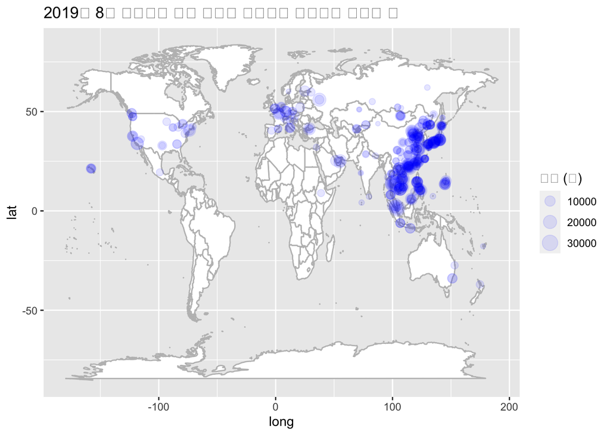

```r
p_point <- p +
  flight2019arr%>% geom_point(mapping=aes(x=longitude, y=latitude, size=유임승객.명.),
                              colour = 'blue',alpha=0.1) +
  labs(title="2019년 8월 인천공항 도착 항공편 출발지별 항공사별 탑승객 수", size="인원 (명)")

p_point
```

Wait, Korean letters are not displayed on the graph. If that’s the case, try below. (if you are using macOS? then 99.9%)

```r
#install.packages("extrafont")
library(extrafont)
font_import(pattern="AppleGothic") # or any font you have on your OS. Like install packages, it is required only for the first time.
```

```
## Importing fonts may take a few minutes, depending on the number of fonts and the speed of the system.
## Continue? [y/n]
```

```r
theme_set(theme_grey(base_family="AppleGothic"))
```

Now try to print out the map again.

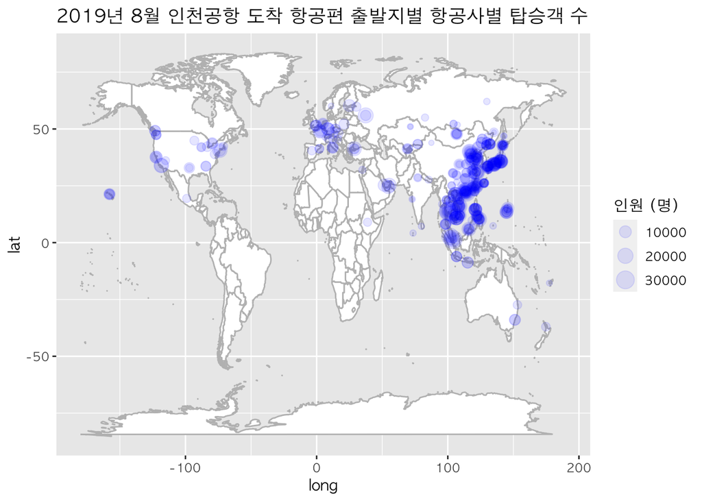

```r
p_point
```

Solved :)

This time, connect the departures to ICN.

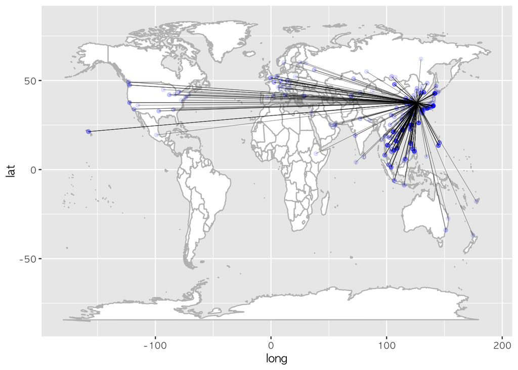

```r
p_line <- p +
  flight2019arr%>% geom_point(mapping=aes(x=longitude, y=latitude),
                              colour = 'blue',alpha=0.1) +
  flight2019arr%>% geom_segment(mapping=aes(y=37.449419, x=126.451328, xend=longitude, yend = latitude), linewidth=0.1 )
p_line
```

Okay, then let’s compare the two major Korean airlines with graphs.

How would you do that?

```r
flight2019arr$항공사명%>%table()%>%sort(decreasing = T)
```

```
## .
##                      대한항공                  아시아나항공
##                           102                            65
##                      제주항공                    티웨이항공
##                            49                            32
##                   이스타 항공                       진 에어
##                            22                            20
##                      에어서울                  중국남방항공
##                            19                            14
##                  중국동방항공                    베트남항공
##                            10                             8
##                  비엣제트항공                  중국국제항공
##                             6                             6
##                      델타항공                      에바항공
##                             4                             4
##    오로라항공 (구 사할린항공)                     피치 항공
##                             4                             4
##              필리핀에어아시아                    필리핀항공
##                             4                             4
##                      산동항공                세부퍼시픽항공
##                             3                             3
##                 시베리아 항공                  아스타나항공
##                             3                             3
##                      인도항공                      중화항공
##                             3                             3
##         가루다 인도네시아항공                루프트한자항공
##                             2                             2
##                      몽골항공              스쿠트타이거항공
##                             2                             2
##                  아메리칸항공                 야쿠티아 항공
##                             2                             2
##               에티오피아 항공                      춘추항공
##                             2                             2
##                    캐나다항공              캐세이퍼시픽항공
##                             2                             2
##                      타이항공 팬퍼시픽항공(구 아스트로항공)
##                             2                             2
##                    AEROMEXICO                 CSA 체코 항공
##                             1                             1
##               KLM네덜란드항공                LOT 폴란드항공
```

[output cut: 14 more lines]

```
##                             1                             1
##              우즈베키스탄항공                유나이티드항공
##                             1                             1
##                      유니항공                  중국하문항공
##                             1                             1
##                      청도항공                    카타르항공
##                             1                             1
##          타이 에어아시아 엑스                      터키항공
##                             1                             1
##           톈진(천진) 에어라인                    프랑스항공
##                             1                             1
##                        핀에어                 하와이안 항공
##                             1                             1
##                홍콩익스프레스                      홍콩항공
##                             1                             1
```

```r
flight2019arr_KE<- flight2019arr %>% filter(항공사명=="대한항공")
flight2019arr_AA<- flight2019arr %>% filter(항공사명=="아시아나항공")
```

And then repeat the same process twice? Well….?

`facet_wrap(vars(grouping variables), nrow= )` : creates graphs for each groups in the grid set by `ncol` or `nrow`

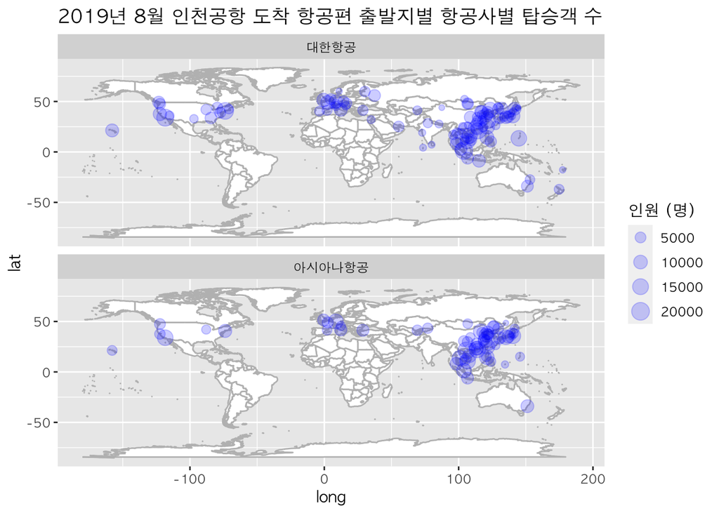

```r
p + flight2019arr%>%filter(항공사명=="대한항공"|항공사명=="아시아나항공") %>%
  geom_point(mapping=aes(x=longitude, y=latitude, size=유임승객.명.),
                                  colour = 'blue',alpha=0.2)+
  facet_wrap(vars(항공사명), nrow=2)+
  labs(title="2019년 8월 인천공항 도착 항공편 출발지별 항공사별 탑승객 수", size="인원 (명)")
```

Let’s compare from different point. Read the data of year 2020 and cleanse it through the same process.

When you repeat the same process for different data, be aware of what point you need to make a change in accordance with the new data.

```r
flight2020_raw<- read.csv(path2, fileEncoding = "cp949")
flight2020_raw<- flight2020_raw%>%
  filter(국제_국내=="국제", 여객_화물=="여객", 년월=="2020-08") %>%
  select(!c(무임승객.명.,환승객.명.,항공화물.kg.,환적화물.kg.,우편물.kg.))

flight2020_code<- flight2020_raw %>% left_join(select(airport,IATA, longitude, latitude), by = c("경유지공항"= "IATA"))
missingIATAlist<-flight2020_code%>%filter(!complete.cases(flight2020_code))%>%select(경유지공항)%>%unique
```

For 2020, there’s only one airport missing the coordinates. And fortunately, it was already included in 2019 also. We are reuse the data then.

```r
flight2020_code$longitude[flight2020_code$경유지공항=="VDO"]<- missingIATA$lon[missingIATA$code=="VDO"]
flight2020_code$latitude[flight2020_code$경유지공항=="VDO"]<- missingIATA$lat[missingIATA$code=="VDO"]

is.na(flight2020_code)%>%table
```

```
## .
## FALSE
##  4472
```

```r
flight2020arr<- flight2020_code%>%filter(도착_출발=="도착")
flight2020dep<- flight2020_code%>%filter(도착_출발=="출발")
```

Marker size based on the number of passengers in 2020.

```r
p_point2020<- p+ flight2020arr%>% geom_point(mapping=aes(x=longitude, y=latitude, size=유임승객.명.),
                                          colour = 'blue',alpha=0.1)+
  labs(title="2020년 8월 인천공항 도착 항공편 출발지별 항공사별 탑승객 수", size="인원 (명)")
```

Let’s put two graphs from different dataframe side by side using `grid.arrange`

```r
#install.packages("gridExtra")
library(gridExtra)
```

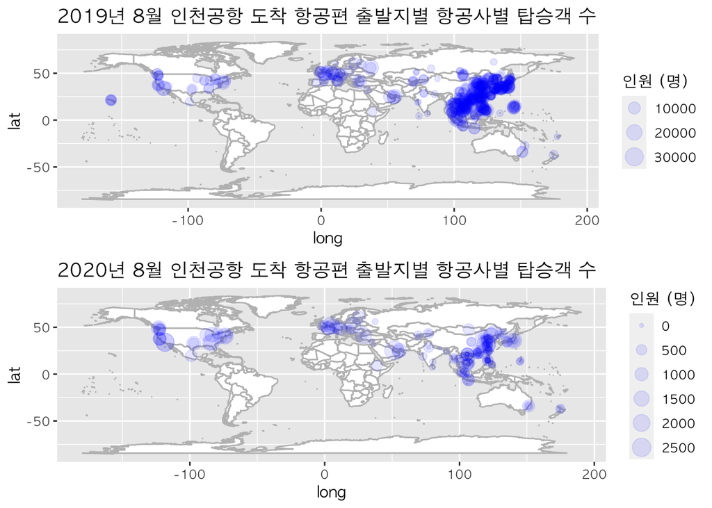

```r
grid.arrange(p_point, p_point2020, nrow=2)
```

##### What can you tell? Any sggestion for improvement?

To apply the same visualization criteria, let’s combine two separate dateframes using `rbind()`

```r
flight2yrs<- rbind(flight2019_code, flight2020_code)
```

In one dataframe? `facet_wrap()`

Another way to set facet variables : .~`var name`

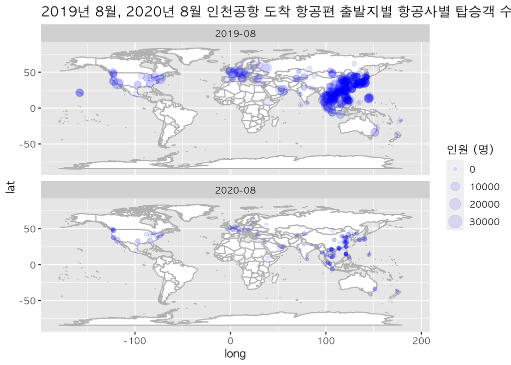

```r
p + flight2yrs%>%filter(도착_출발=="도착")%>% geom_point(mapping=aes(x=longitude, y=latitude, size=유임승객.명.),
                                colour = 'blue',alpha=0.1) +
  facet_wrap(.~ 년월, nrow=2) +
  labs(title="2019년 8월, 2020년 8월 인천공항 도착 항공편 출발지별 항공사별 탑승객 수", size="인원 (명)")
```

we can even apply two variables for facet.

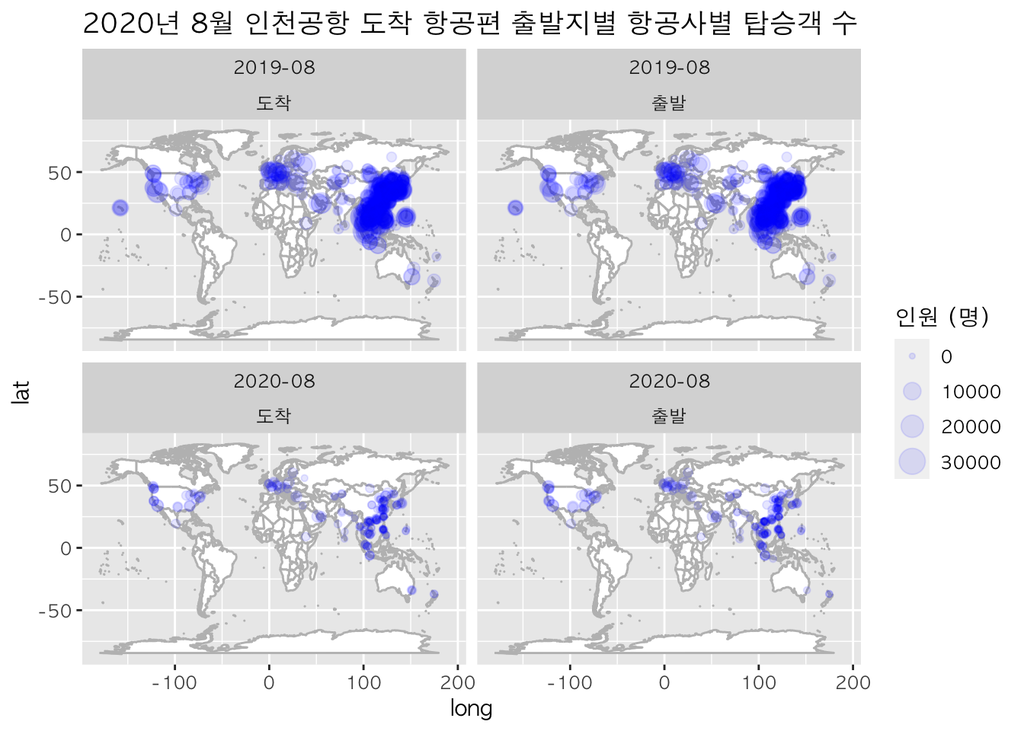

```r
p_point_1920<- p + flight2yrs%>% geom_point(mapping=aes(x=longitude, y=latitude, size=유임승객.명.),
                                            colour = 'blue',alpha=0.1) +
  facet_wrap(.~ 년월 +도착_출발 , nrow=2) +
  labs(title="2020년 8월 인천공항 도착 항공편 출발지별 항공사별 탑승객 수", size="인원 (명)")

p_point_1920
```

Lastly, let’s save the chart using `ggsave()`.

It saves the last plot you displayed.

```r
ggsave("ArrICN_19n20Aug.png", width = 11, height = 8, units = "in")
```

### 🟪 Assignment.

##### Create two comparison charts using today’s dataset. (other than what we practiced together in class)

Submit your * R code file * charts * thoughts on the result in text

Read csv file from * flight data : https://github.com/czeropark/CAU23R/tree/main/W11_data * airport data: https://raw.githubusercontent.com/jpatokal/openflights/master/data/airports.dat

(For flight data, click csv file and then click “raw” button so that you can copy the url like in the page for the airport data)

For example, you will read csv file using **url** like below, instead of from the path to your local folder.

`read.csv("https://raw.githubusercontent.com/czeropark/CAU23R/main/W11_data/2018_full.csv", fileEncoding="cp949")`

- 2018_full.csv: 노선별 항공사별 항공운송실적(2018년 전체).csv
- 2019_full.csv: 노선별 항공사별 항공운송실적(2019년 전체).csv
- 2020_1half.csv: 노선별 항공사별 항공운송실적(2020년 상반기).csv
- 2020_full.csv: 노선별 항공사별 항공운송실적(2020년 전체).csv
- 2021_1half.csv: 노선별 항공사별 항공운송실적(2021년 상반기).csv
- 2021_full.csv: 노선별 항공사별 항공운송실적(2021년 전체).csv
- 2022_1half.csv:노선별 항공사별 항공운송실적(2022년 상반기).csv

##### **Due: Nov.28 23:59**